# Repeated measures analyses

```r
library(nlme)
library(ggplot2)
library(multcomp)
library(emmeans)
library(rstatix)
library(ggpubr)
require(tidyverse)
library(pheatmap)
require(RColorBrewer)

color_panel<-c("#e35d6a","#5bb75b","#428bca","#e87810","#23496b","#ffbf00","#cc2028","#039748","pink","gray","darkgray")

set.seed(189672)
```

# 1 Introduction

For every metric used to compare kit-tube combinations, we tested the possibility of interaction. We build a linear mixed-effects model with tube, RNA isolation kit and timelapse as fixed effects and donorID as random effect. The heteroscedasticity introduced by different RNAisolation kits was taken into account.

# 2 Annotation

Sample annotation with info about tube, kit, used input volume, eluate volume etc., volume unit is µL.

```r
samples<-read_csv("./docs/Annotation_exRNAQC017_RNA-Exome_withHemolysis.csv")
samples<-samples %>% mutate(donorID= case_when((Donor == "PNL-ZT37") ~ "D5",
                                                                   (Donor == "PNL-RM7B") ~ "D1",
                                                                   (Donor == "PNL-QJMM") ~ "D2",
                                                                   (Donor == "PNL-2AAR") ~ "D3",
                                                                   (Donor == "PNL-XNID") ~ "D4"),
                                                SampleID= paste0(GraphKit,"_",GraphTube,"_",TimeLapse,"_",donorID),
                                                tube_kitID=paste0(GraphTube,"_",GraphKit),
                                                tube_kit_timeID=paste0(GraphTube,"_",GraphKit,"_",TimeLapse),
                                                PlasmaInputVml= PlasmaInputV/1000)

DT::datatable(samples %>% dplyr::select(c("RNAID","donorID","RNAisolation","Tube","TimeLapse","PlasmaInputV","Sequinconc","EluateV","ERCCconc","RNAinputV", "Hemolysis",Abbrevation="GraphKit")), rownames = TRUE, filter="top", options = list(pageLength = 10, scrollX=T), caption = "Sample annotation table")
```

|  | RNAID | donorID | RNAisolation | Tube | TimeLapse | PlasmaInputV | Sequinconc | EluateV | ERCCconc | RNAinputV | Hemolysis | Abbrevation |
| --- | --- | --- | --- | --- | --- | --- | --- | --- | --- | --- | --- | --- |
| 1 | RNA014899 | D1 | miRNeasySPkit | Citrate | T0 | 200 | 1/1000000 | 14 | 1/500000 | 8.5 | 0.013 | MIR0.2 |
| 2 | RNA014898 | D2 | miRNeasySPkit | Citrate | T0 | 200 | 1/1000000 | 14 | 1/500000 | 8.5 | 0.013 | MIR0.2 |
| 3 | RNA014897 | D3 | miRNeasySPkit | Citrate | T0 | 200 | 1/1000000 | 14 | 1/500000 | 8.5 | 0.009 | MIR0.2 |
| 4 | RNA014919 | D4 | miRNeasySPkit | Citrate | T0 | 200 | 1/1000000 | 14 | 1/500000 | 8.5 | 0.137 | MIR0.2 |
| 5 | RNA014933 | D5 | miRNeasySPkit | Citrate | T0 | 200 | 1/1000000 | 14 | 1/500000 | 8.5 | 0.03 | MIR0.2 |
| 6 | RNA014890 | D1 | miRNeasySPkit | Citrate | T04 | 200 | 1/1000000 | 14 | 1/500000 | 8.5 | 0.013 | MIR0.2 |
| 7 | RNA014902 | D2 | miRNeasySPkit | Citrate | T04 | 200 | 1/1000000 | 14 | 1/500000 | 8.5 | 0.069 | MIR0.2 |
| 8 | RNA014923 | D3 | miRNeasySPkit | Citrate | T04 | 200 | 1/1000000 | 14 | 1/500000 | 8.5 | 0.019 | MIR0.2 |
| 9 | RNA014913 | D4 | miRNeasySPkit | Citrate | T04 | 200 | 1/1000000 | 14 | 1/500000 | 8.5 | 0.119 | MIR0.2 |
| 10 | RNA014903 | D5 | miRNeasySPkit | Citrate | T04 | 200 | 1/1000000 | 14 | 1/500000 | 8.5 | 0.029 | MIR0.2 |

[output cut: 80 more lines]

```r
samples$Tube<-as.factor(samples$Tube)
samples$RNAisolation<-as.factor(samples$RNAisolation)
samples$TimeLapse<-as.factor(samples$TimeLapse)
samples$donorID<-as.factor(samples$donorID)

Tube.levels<-levels(samples$Tube)
RNAisolation.levels<-levels(samples$RNAisolation)
TimeLapse.levels<-levels(samples$TimeLapse)
```

# 3 Sequencing and preprocessing

## 3.1 Reads

```r
r_stat <- read.csv('./data_output/reads_melt_pre.csv',sep=",",header = TRUE)

r_stat$Tube<-as.factor(r_stat$Tube)
r_stat$RNAisolation<-as.factor(r_stat$RNAisolation)
r_stat$TimeLapse<-as.factor(r_stat$TimeLapse)
r_stat$donorID<-as.factor(r_stat$donorID)

Tube.levels<-levels(r_stat$Tube)
RNAisolation.levels<-levels(r_stat$RNAisolation)
TimeLapse.levels<-levels(r_stat$TimeLapse)
```

Linear mixed-effects model with crossed fixed effects of tube, kit and timelapse.

```r
m1<-lme(reads~Tube*RNAisolation*TimeLapse,
       random=~1|donorID,
       weights = varIdent(form = ~ 1 | RNAisolation),
       data=r_stat)

anova(m1)
```

```
##                             numDF denDF   F-value p-value
## (Intercept)                     1    68 1144.7625  <.0001
## Tube                            2    68    0.6097  0.5464
## RNAisolation                    1    68   14.2283  0.0003
## TimeLapse                       2    68    0.4590  0.6339
## Tube:RNAisolation               2    68    0.9622  0.3872
## Tube:TimeLapse                  4    68    0.3651  0.8327
## RNAisolation:TimeLapse          2    68    0.3767  0.6875
## Tube:RNAisolation:TimeLapse     4    68    0.2433  0.9128
```

```r
anova_m1 <- round(anova(m1)[c(5, 6, 7), c(4)], digits = 3)
```

Only RNAisolation kit has a significant effect, there are no interactions.

The normality of the residuals is checked.

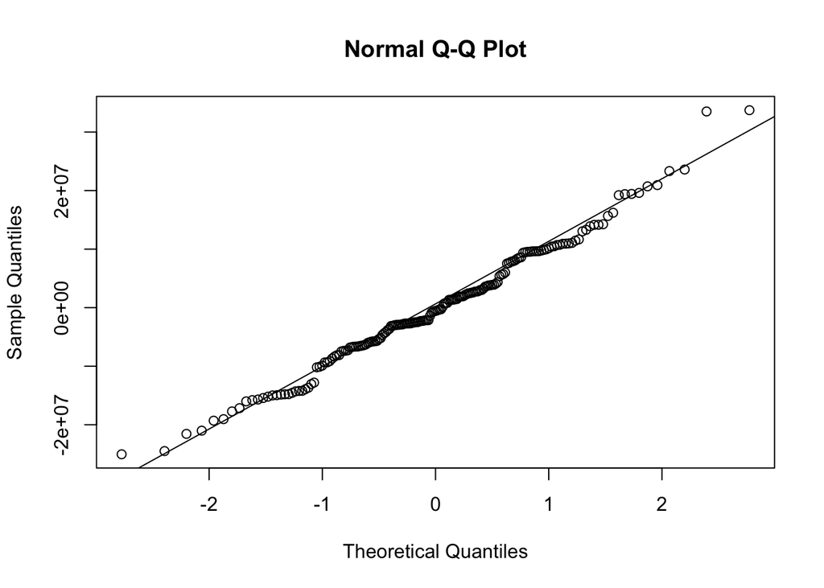

```r
qqnorm(m1$residuals)
qqline(m1$residuals)
```

## 3.2 Kallisto alignment score

```r
align_stat <- read.csv('./data_output/kallisto_aligned.csv',sep=",",header = TRUE)

align_stat$Tube<-as.factor(align_stat$Tube)
align_stat$RNAisolation<-as.factor(align_stat$RNAisolation)
align_stat$TimeLapse<-as.factor(align_stat$TimeLapse)
align_stat$donorID<-as.factor(align_stat$donorID)

Tube.levels<-levels(align_stat$Tube)
RNAisolation.levels<-levels(align_stat$RNAisolation)
TimeLapse.levels<-levels(align_stat$TimeLapse)
```

Linear mixed-effects model with crossed fixed effects of tube, kit and timelapse.

```r
align_m1<-lme(percent_aligned~Tube*RNAisolation*TimeLapse,
       random=~1|donorID,
       weights = varIdent(form = ~ 1 | RNAisolation),
       data=align_stat)

anova_align_m1 <- round(anova(align_m1)[c(5, 6, 7), c(4)], digits = 3)
anova(align_m1)
```

```
##                             numDF denDF   F-value p-value
## (Intercept)                     1    68 2591.7871  <.0001
## Tube                            2    68   15.6366  <.0001
## RNAisolation                    1    68    1.3057  0.2572
## TimeLapse                       2    68    0.5747  0.5656
## Tube:RNAisolation               2    68    7.3842  0.0013
## Tube:TimeLapse                  4    68    1.8605  0.1275
## RNAisolation:TimeLapse          2    68    1.7693  0.1782
## Tube:RNAisolation:TimeLapse     4    68    1.6238  0.1783
```

There seems to be an interaction between tube and RNA isolation kit. There is no third-order interaction with time. Next, we look at second-order interactions:

```r
align_m2<-lme(percent_aligned~(Tube+RNAisolation+TimeLapse)^2,
       random=~1|donorID,
       weights = varIdent(form = ~ 1 | RNAisolation),
       data=align_stat)

anova(align_m2)
```

```
##                        numDF denDF   F-value p-value
## (Intercept)                1    72 2589.3099  <.0001
## Tube                       2    72   14.9891  <.0001
## RNAisolation               1    72    1.2600  0.2654
## TimeLapse                  2    72    0.5656  0.5705
## Tube:RNAisolation          2    72    7.1253  0.0015
## Tube:TimeLapse             4    72    1.7972  0.1388
## RNAisolation:TimeLapse     2    72    1.7073  0.1886
```

Again, we see an interaction between tube and kit. Finally, we only include the tube-kit interaction in the model.

```r
align_m3<-lme(percent_aligned~Tube+RNAisolation+TimeLapse+
             Tube:RNAisolation,
       random=~1|donorID,
       weights = varIdent(form = ~ 1 | RNAisolation),
       data=align_stat)

anova(align_m3)
```

```
##                   numDF denDF   F-value p-value
## (Intercept)           1    78 2581.7144  <.0001
## Tube                  2    78   13.8071  <.0001
## RNAisolation          1    78    1.1834  0.2800
## TimeLapse             2    78    0.5650  0.5707
## Tube:RNAisolation     2    78    6.6926  0.0021
```

The normality of the residuals is checked.

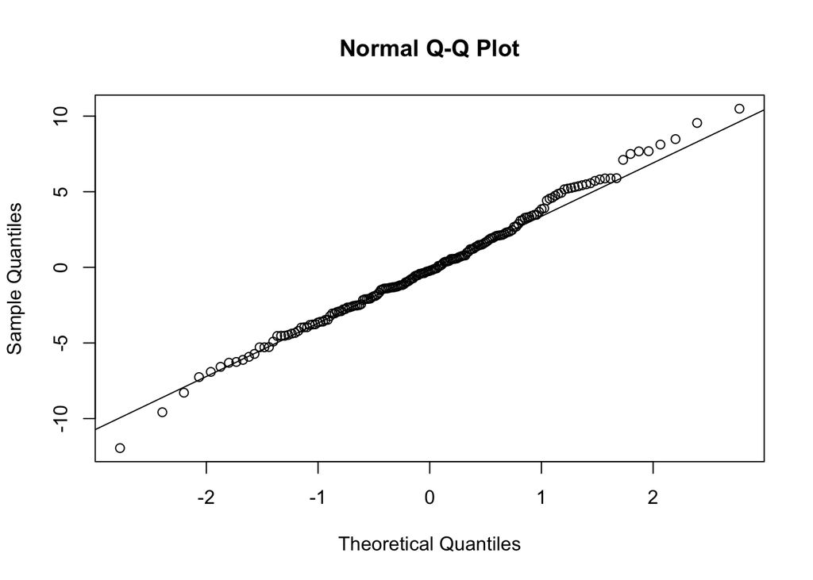

```r
qqnorm(align_m3$residuals)
qqline(align_m3$residuals)
```

For both RNA isolation methods, the effect of tube is investigated. The data is collapsed over time.

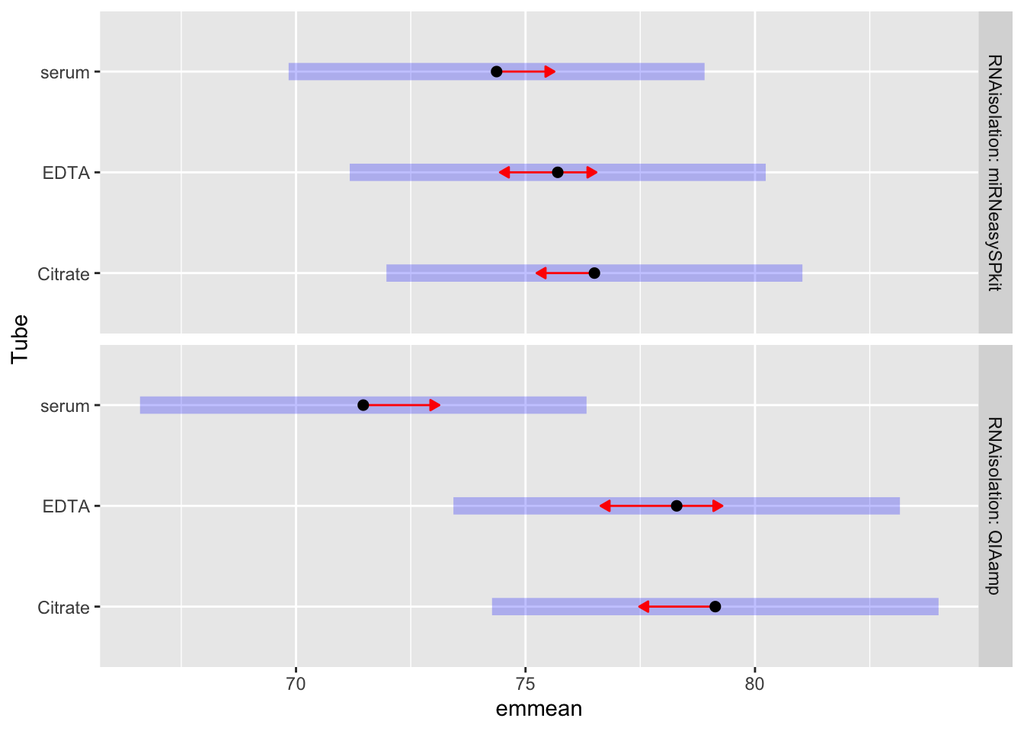

```r
align_m.methods<-emmeans(align_m3, ~Tube|RNAisolation)
plot(align_m.methods, comparisons=TRUE)
```

The arrows in the plot originate in the estimated marginal mean of that group, the length is an approximation of the margin of error if compared with the marginal mean of the closest other group. The arrow is one-sided if there is no other group with a smaller (to the left) or bigger (to the right) marginal mean to compare with. If the arrows of two groups overlap, it means that the margin of error is bigger than the difference. If there is no overlap, which we see in the serum tube group if extracted with the QIAamp kit, it means that the difference is bigger than the margin or error. Thus, there is a significant difference.

```r
pairs(align_m.methods)
```

```
## RNAisolation = miRNeasySPkit:
##  contrast        estimate   SE df t.ratio p.value
##  Citrate - EDTA     0.799 1.05 78   0.759  0.7294
##  Citrate - serum    2.131 1.05 78   2.023  0.1135
##  EDTA - serum       1.332 1.05 78   1.264  0.4196
##
## RNAisolation = QIAamp:
##  contrast        estimate   SE df t.ratio p.value
##  Citrate - EDTA     0.841 1.39 78   0.607  0.8168
##  Citrate - serum    7.669 1.39 78   5.532  <.0001
##  EDTA - serum       6.828 1.39 78   4.925  <.0001
##
## Results are averaged over the levels of: TimeLapse
## Degrees-of-freedom method: containment
## P value adjustment: tukey method for comparing a family of 3 estimates
```

```r
confint(align_m.methods, adjust="mvt")
```

```
## RNAisolation = miRNeasySPkit:
##  Tube    emmean   SE df lower.CL upper.CL
##  Citrate   76.5 1.63  4     71.0     82.0
##  EDTA      75.7 1.63  4     70.2     81.2
##  serum     74.4 1.63  4     68.9     79.9
##
## RNAisolation = QIAamp:
##  Tube    emmean   SE df lower.CL upper.CL
##  Citrate   79.1 1.75  4     73.0     85.3
##  EDTA      78.3 1.75  4     72.2     84.4
##  serum     71.5 1.75  4     65.3     77.6
##
## Results are averaged over the levels of: TimeLapse
## Degrees-of-freedom method: containment
## Confidence level used: 0.95
## Conf-level adjustment: mvt method for 3 estimates
```

We can conclude that the alignment percentage is significantly lower in the serum tube compared to the other tubes, but only if extracted with the QIAamp kit.

```r
# ANOVA test between tubes of same kit
align_stats <- align_stat %>% group_by(RNAisolation, Tube) %>% get_summary_stats(percent_aligned, type = "mean_sd")
align_tube_effect <- align_stat %>% group_by(RNAisolation) %>% anova_test(percent_aligned ~ Tube)
```

```
## Coefficient covariances computed by hccm()
## Coefficient covariances computed by hccm()
```

```r
align_kit_effect <- align_stat %>% group_by(Tube) %>% anova_test(percent_aligned ~ RNAisolation)
```

```
## Coefficient covariances computed by hccm()
## Coefficient covariances computed by hccm()
## Coefficient covariances computed by hccm()
```

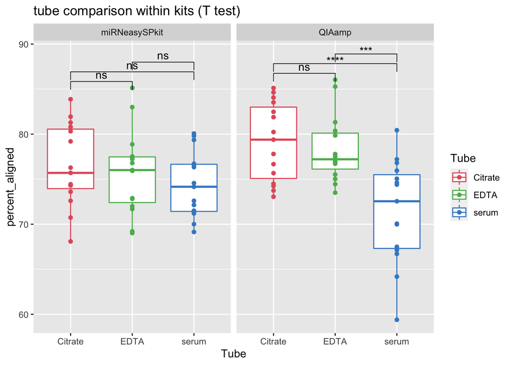

```r
# Pairwise comparisons
align_pwc <- align_stat %>% group_by(RNAisolation) %>% pairwise_t_test(percent_aligned ~ Tube) %>% add_xy_position(x = "Tube")
align_pwc_time <- align_stat %>% group_by(RNAisolation, TimeLapse) %>% pairwise_t_test(percent_aligned ~ Tube) %>% add_xy_position(x = "Tube")

# Show p-values
ggplot(align_stat, aes(x = Tube, y = percent_aligned, color = Tube)) +
  geom_boxplot() +
  geom_point() +
  scale_colour_manual(values=color_panel) +
  facet_wrap(~ RNAisolation) +
  stat_pvalue_manual(align_pwc, label = "p.signif") +
  labs(title = "tube comparison within kits (T test)")
```

```r
#ggsave("./data_output/plots/duplicates_stats.pdf", plot = ggplot2::last_plot(), dpi = 300)
```

## 3.3 Duplicate rate

```r
dupl_stat<-read.csv("./data_output/duplicates_complete.csv",sep=",",header = TRUE)

dupl_stat$Tube<-as.factor(dupl_stat$Tube)
dupl_stat$RNAisolation<-as.factor(dupl_stat$RNAisolation)
dupl_stat$TimeLapse<-as.factor(dupl_stat$TimeLapse)
dupl_stat$donorID<-as.factor(dupl_stat$donorID)

Tube.levels<-levels(dupl_stat$Tube)
RNAisolation.levels<-levels(dupl_stat$RNAisolation)
TimeLapse.levels<-levels(dupl_stat$TimeLapse)
```

Linear mixed-effects model with crossed fixed effects of tube, kit and timelapse.

```r
#dupl_m <- aov(duplicates ~ RNAisolation*Tube*TimeLapse, dupl_stat)
#summary(dupl_m)
#dupl_m_RM <- aov(duplicates ~ RNAisolation*Tube*TimeLapse + Error(donorID), dupl_stat)
#summary(dupl_m_RM)

dupl_m1<-lme(duplicates~Tube*RNAisolation*TimeLapse,
       random=~1|donorID,
       weights = varIdent(form = ~ 1 | RNAisolation),
       data=dupl_stat)

anova_dupl_m1 <- round(anova(dupl_m1)[c(5, 6, 7), c(4)], digits = 3)
anova(dupl_m1)
```

```
##                             numDF denDF   F-value p-value
## (Intercept)                     1    68 143322.29  <.0001
## Tube                            2    68      0.28  0.7571
## RNAisolation                    1    68    285.44  <.0001
## TimeLapse                       2    68      1.13  0.3276
## Tube:RNAisolation               2    68      7.51  0.0011
## Tube:TimeLapse                  4    68      2.51  0.0499
## RNAisolation:TimeLapse          2    68      0.98  0.3823
## Tube:RNAisolation:TimeLapse     4    68      0.84  0.5058
```

The model indicates that there are interaction effects with Tube. Thus the effect of RNA isolation method is not the same for all tubes, and the effect of time is not the same for all tubes. However, there is no significant third-order interaction. Next, we look at second-order interactions:

```r
dupl_m2<-lme(duplicates~(Tube+RNAisolation+TimeLapse)^2,
       random=~1|donorID,
       weights = varIdent(form = ~ 1 | RNAisolation),
       data=dupl_stat)

anova(dupl_m2)
```

```
##                        numDF denDF   F-value p-value
## (Intercept)                1    72 143067.36  <.0001
## Tube                       2    72      0.29  0.7485
## RNAisolation               1    72    289.24  <.0001
## TimeLapse                  2    72      1.15  0.3239
## Tube:RNAisolation          2    72      7.61  0.0010
## Tube:TimeLapse             4    72      2.53  0.0480
## RNAisolation:TimeLapse     2    72      0.99  0.3772
```

Again, we see interaction effects with Tube. Finally, we only include the tube-kit and tube-time effect in the model.

```r
dupl_m3<-lme(duplicates~Tube+RNAisolation+TimeLapse+
             Tube:RNAisolation+Tube:TimeLapse,
       random=~1|donorID,
       weights = varIdent(form = ~ 1 | RNAisolation),
       data=dupl_stat)

anova(dupl_m3)
```

```
##                   numDF denDF   F-value p-value
## (Intercept)           1    74 143058.62  <.0001
## Tube                  2    74      0.29  0.7482
## RNAisolation          1    74    289.37  <.0001
## TimeLapse             2    74      1.15  0.3236
## Tube:RNAisolation     2    74      7.62  0.0010
## Tube:TimeLapse        4    74      2.53  0.0477
```

A quick check of the normality of the residuals. There seem to be some deviation in the tails. However, the methods used here are quite robust against such deviations.

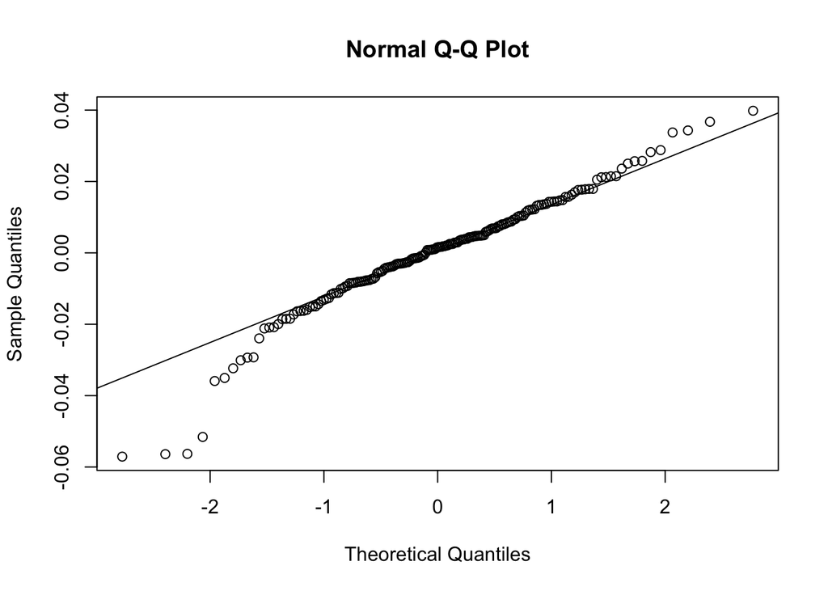

```r
qqnorm(dupl_m3$residuals)
qqline(dupl_m3$residuals)
```

For all combinations of tube and RNA isolation method, the effect of time is investigated. Tukey’s method for multiplicity correction is applied separately for each combination of tube and RNA isolation method. Hardly any significant time effects are detected. If multiple testing correction would have been applied to all test simultaneously, no significant results would have been left.

Note that this analysis is based on the method that includes all interaction terms, whereas a previous analysis has suggested that there is only evidence for interaction effects with tube. We believe it is still better to do this analysis under a less restrictive model (as we have done here).

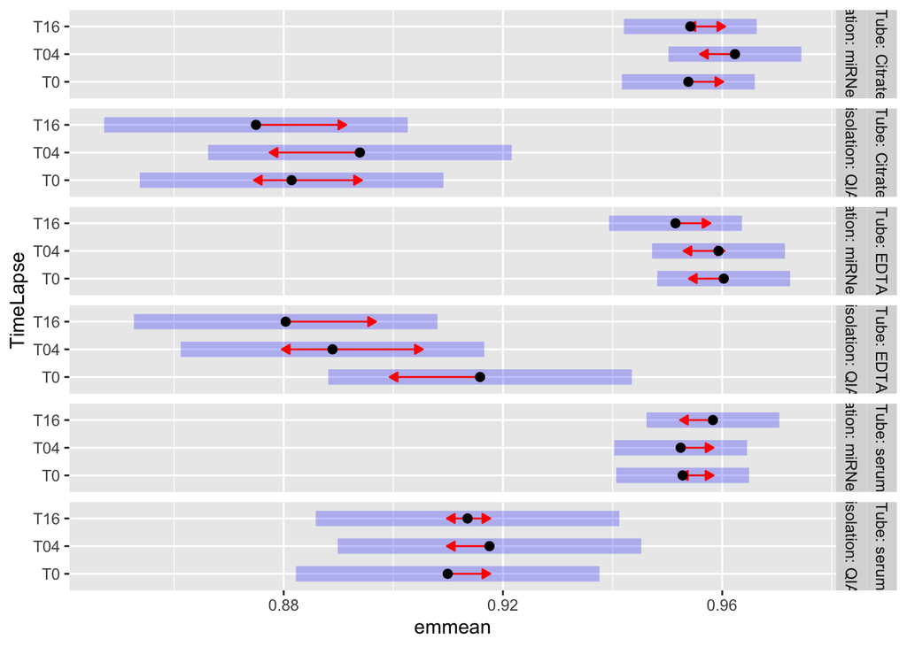

```r
dupl_m.time<-emmeans(dupl_m1, ~TimeLapse|Tube:RNAisolation)
plot(dupl_m.time, comparisons=TRUE)
```

```r
pairs(dupl_m.time)
```

```
## Tube = Citrate, RNAisolation = miRNeasySPkit:
##  contrast  estimate      SE df t.ratio p.value
##  T0 - T04  -0.00850 0.00532 68  -1.598  0.2536
##  T0 - T16  -0.00036 0.00532 68  -0.068  0.9975
##  T04 - T16  0.00814 0.00532 68   1.530  0.2834
##
## Tube = EDTA, RNAisolation = miRNeasySPkit:
##  contrast  estimate      SE df t.ratio p.value
##  T0 - T04   0.00096 0.00532 68   0.180  0.9822
##  T0 - T16   0.00880 0.00532 68   1.654  0.2304
##  T04 - T16  0.00784 0.00532 68   1.474  0.3099
##
## Tube = serum, RNAisolation = miRNeasySPkit:
##  contrast  estimate      SE df t.ratio p.value
##  T0 - T04   0.00036 0.00532 68   0.068  0.9975
##  T0 - T16  -0.00552 0.00532 68  -1.038  0.5559
##  T04 - T16 -0.00588 0.00532 68  -1.105  0.5142
##
## Tube = Citrate, RNAisolation = QIAamp:
##  contrast  estimate      SE df t.ratio p.value
##  T0 - T04  -0.01246 0.01375 68  -0.906  0.6385
##  T0 - T16   0.00650 0.01375 68   0.473  0.8844
##  T04 - T16  0.01896 0.01375 68   1.378  0.3578
##
## Tube = EDTA, RNAisolation = QIAamp:
##  contrast  estimate      SE df t.ratio p.value
##  T0 - T04   0.02692 0.01375 68   1.957  0.1308
##  T0 - T16   0.03546 0.01375 68   2.578  0.0321
##  T04 - T16  0.00854 0.01375 68   0.621  0.8092
##
## Tube = serum, RNAisolation = QIAamp:
##  contrast  estimate      SE df t.ratio p.value
##  T0 - T04  -0.00762 0.01375 68  -0.554  0.8448
##  T0 - T16  -0.00362 0.01375 68  -0.263  0.9626
##  T04 - T16  0.00400 0.01375 68   0.291  0.9545
##
## Degrees-of-freedom method: containment
## P value adjustment: tukey method for comparing a family of 3 estimates
```

```r
confint(dupl_m.time,adjust="mvt")
```

```
## Tube = Citrate, RNAisolation = miRNeasySPkit:
##  TimeLapse emmean      SE df lower.CL upper.CL
##  T0         0.954 0.00437  4    0.938    0.970
##  T04        0.962 0.00437  4    0.946    0.979
##  T16        0.954 0.00437  4    0.938    0.970
##
## Tube = EDTA, RNAisolation = miRNeasySPkit:
##  TimeLapse emmean      SE df lower.CL upper.CL
##  T0         0.960 0.00437  4    0.944    0.976
##  T04        0.959 0.00437  4    0.943    0.976
##  T16        0.951 0.00437  4    0.935    0.968
##
## Tube = serum, RNAisolation = miRNeasySPkit:
##  TimeLapse emmean      SE df lower.CL upper.CL
##  T0         0.953 0.00437  4    0.937    0.969
##  T04        0.952 0.00437  4    0.936    0.969
##  T16        0.958 0.00437  4    0.942    0.975
##
## Tube = Citrate, RNAisolation = QIAamp:
##  TimeLapse emmean      SE df lower.CL upper.CL
##  T0         0.881 0.00997  4    0.844    0.919
##  T04        0.894 0.00997  4    0.857    0.931
##  T16        0.875 0.00997  4    0.838    0.912
##
## Tube = EDTA, RNAisolation = QIAamp:
##  TimeLapse emmean      SE df lower.CL upper.CL
##  T0         0.916 0.00997  4    0.878    0.953
##  T04        0.889 0.00997  4    0.852    0.926
##  T16        0.880 0.00997  4    0.843    0.918
##
## Tube = serum, RNAisolation = QIAamp:
##  TimeLapse emmean      SE df lower.CL upper.CL
##  T0         0.910 0.00997  4    0.872    0.947
##  T04        0.918 0.00997  4    0.880    0.955
##  T16        0.914 0.00997  4    0.876    0.951
##
## Degrees-of-freedom method: containment
## Confidence level used: 0.95
## Conf-level adjustment: mvt method for 3 estimates
```

Next we compare all methods (i.e. combination of tube and RNA isolation method) in a pairwise fashion, but for each time point separately. Again Tukey’s multiple testing method is used, for each time point separately.

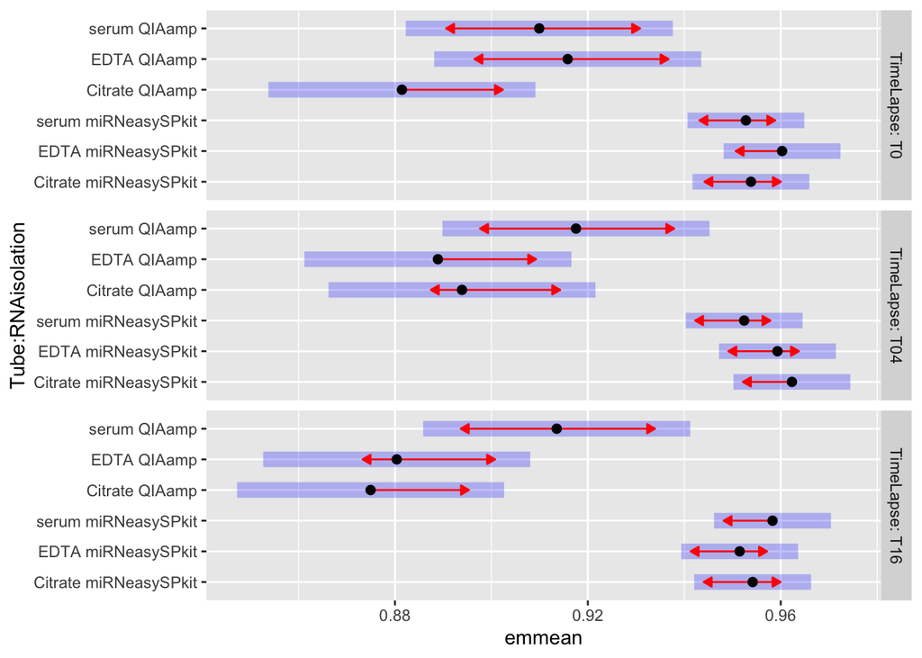

```r
dupl_m.methods<-emmeans(dupl_m1, ~Tube*RNAisolation|TimeLapse)
plot(dupl_m.methods, comparisons=TRUE)
```

```r
pairs(dupl_m.methods)
```

```
## TimeLapse = T0:
##  contrast                                    estimate      SE df t.ratio
##  Citrate miRNeasySPkit - EDTA miRNeasySPkit  -0.00646 0.00532 68  -1.214
##  Citrate miRNeasySPkit - serum miRNeasySPkit  0.00104 0.00532 68   0.195
##  Citrate miRNeasySPkit - Citrate QIAamp       0.07238 0.01043 68   6.941
##  Citrate miRNeasySPkit - EDTA QIAamp          0.03800 0.01043 68   3.644
##  Citrate miRNeasySPkit - serum QIAamp         0.04390 0.01043 68   4.210
##  EDTA miRNeasySPkit - serum miRNeasySPkit     0.00750 0.00532 68   1.410
##  EDTA miRNeasySPkit - Citrate QIAamp          0.07884 0.01043 68   7.560
##  EDTA miRNeasySPkit - EDTA QIAamp             0.04446 0.01043 68   4.264
##  EDTA miRNeasySPkit - serum QIAamp            0.05036 0.01043 68   4.829
##  serum miRNeasySPkit - Citrate QIAamp         0.07134 0.01043 68   6.841
##  serum miRNeasySPkit - EDTA QIAamp            0.03696 0.01043 68   3.544
##  serum miRNeasySPkit - serum QIAamp           0.04286 0.01043 68   4.110
##  Citrate QIAamp - EDTA QIAamp                -0.03438 0.01375 68  -2.500
##  Citrate QIAamp - serum QIAamp               -0.02848 0.01375 68  -2.071
##  EDTA QIAamp - serum QIAamp                   0.00590 0.01375 68   0.429
##  p.value
##   0.8284
##   1.0000
##   <.0001
##   0.0066
##   0.0010
##   0.7211
##   <.0001
##   0.0009
##   0.0001
##   <.0001
##   0.0090
##   0.0015
##   0.1387
##   0.3149
##   0.9981
##
## TimeLapse = T04:
##  contrast                                    estimate      SE df t.ratio
##  Citrate miRNeasySPkit - EDTA miRNeasySPkit   0.00300 0.00532 68   0.564
##  Citrate miRNeasySPkit - serum miRNeasySPkit  0.00990 0.00532 68   1.861
##  Citrate miRNeasySPkit - Citrate QIAamp       0.06842 0.01043 68   6.561
##  Citrate miRNeasySPkit - EDTA QIAamp          0.07342 0.01043 68   7.041
```

[output cut: 49 more lines]

```
##   <.0001
##   0.0030
##   0.7938
##   <.0001
##   <.0001
##   0.0067
##   <.0001
##   <.0001
##   0.0008
##   0.9987
##   0.0685
##   0.1666
##
## Degrees-of-freedom method: containment
## P value adjustment: tukey method for comparing a family of 6 estimates
```

```r
confint(dupl_m.methods, adjust="mvt")
```

```
## TimeLapse = T0:
##  Tube    RNAisolation  emmean      SE df lower.CL upper.CL
##  Citrate miRNeasySPkit  0.954 0.00437  4    0.935    0.973
##  EDTA    miRNeasySPkit  0.960 0.00437  4    0.941    0.979
##  serum   miRNeasySPkit  0.953 0.00437  4    0.934    0.972
##  Citrate QIAamp         0.881 0.00997  4    0.838    0.925
##  EDTA    QIAamp         0.916 0.00997  4    0.872    0.959
##  serum   QIAamp         0.910 0.00997  4    0.867    0.953
##
## TimeLapse = T04:
##  Tube    RNAisolation  emmean      SE df lower.CL upper.CL
##  Citrate miRNeasySPkit  0.962 0.00437  4    0.943    0.981
##  EDTA    miRNeasySPkit  0.959 0.00437  4    0.940    0.978
##  serum   miRNeasySPkit  0.952 0.00437  4    0.933    0.971
##  Citrate QIAamp         0.894 0.00997  4    0.851    0.937
##  EDTA    QIAamp         0.889 0.00997  4    0.846    0.932
##  serum   QIAamp         0.918 0.00997  4    0.874    0.961
##
## TimeLapse = T16:
##  Tube    RNAisolation  emmean      SE df lower.CL upper.CL
##  Citrate miRNeasySPkit  0.954 0.00437  4    0.935    0.973
##  EDTA    miRNeasySPkit  0.951 0.00437  4    0.933    0.970
##  serum   miRNeasySPkit  0.958 0.00437  4    0.939    0.977
##  Citrate QIAamp         0.875 0.00997  4    0.832    0.918
##  EDTA    QIAamp         0.880 0.00997  4    0.837    0.924
##  serum   QIAamp         0.914 0.00997  4    0.870    0.957
##
## Degrees-of-freedom method: containment
## Confidence level used: 0.95
## Conf-level adjustment: mvt method for 6 estimates
```

Compare for each timepoint-kit combination separately

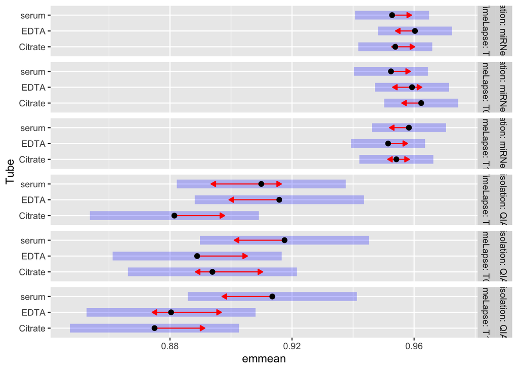

```r
dupl_m.time_kit<-emmeans(dupl_m1, ~Tube|RNAisolation:TimeLapse )
plot(dupl_m.time_kit, comparisons=TRUE)
```

```r
pairs(dupl_m.time_kit)
```

```
## RNAisolation = miRNeasySPkit, TimeLapse = T0:
##  contrast        estimate      SE df t.ratio p.value
##  Citrate - EDTA  -0.00646 0.00532 68  -1.214  0.4489
##  Citrate - serum  0.00104 0.00532 68   0.195  0.9792
##  EDTA - serum     0.00750 0.00532 68   1.410  0.3416
##
## RNAisolation = QIAamp, TimeLapse = T0:
##  contrast        estimate      SE df t.ratio p.value
##  Citrate - EDTA  -0.03438 0.01375 68  -2.500  0.0390
##  Citrate - serum -0.02848 0.01375 68  -2.071  0.1036
##  EDTA - serum     0.00590 0.01375 68   0.429  0.9037
##
## RNAisolation = miRNeasySPkit, TimeLapse = T04:
##  contrast        estimate      SE df t.ratio p.value
##  Citrate - EDTA   0.00300 0.00532 68   0.564  0.8397
##  Citrate - serum  0.00990 0.00532 68   1.861  0.1580
##  EDTA - serum     0.00690 0.00532 68   1.297  0.4018
##
## RNAisolation = QIAamp, TimeLapse = T04:
##  contrast        estimate      SE df t.ratio p.value
##  Citrate - EDTA   0.00500 0.01375 68   0.364  0.9298
##  Citrate - serum -0.02364 0.01375 68  -1.719  0.2056
##  EDTA - serum    -0.02864 0.01375 68  -2.082  0.1011
##
## RNAisolation = miRNeasySPkit, TimeLapse = T16:
##  contrast        estimate      SE df t.ratio p.value
##  Citrate - EDTA   0.00270 0.00532 68   0.508  0.8679
##  Citrate - serum -0.00412 0.00532 68  -0.774  0.7199
##  EDTA - serum    -0.00682 0.00532 68  -1.282  0.4102
##
## RNAisolation = QIAamp, TimeLapse = T16:
##  contrast        estimate      SE df t.ratio p.value
##  Citrate - EDTA  -0.00542 0.01375 68  -0.394  0.9181
##  Citrate - serum -0.03860 0.01375 68  -2.806  0.0177
##  EDTA - serum    -0.03318 0.01375 68  -2.412  0.0481
##
## Degrees-of-freedom method: containment
## P value adjustment: tukey method for comparing a family of 3 estimates
```

```r
confint(dupl_m.time_kit, adjust="mvt")
```

```
## RNAisolation = miRNeasySPkit, TimeLapse = T0:
##  Tube    emmean      SE df lower.CL upper.CL
##  Citrate  0.954 0.00437  4    0.938    0.970
##  EDTA     0.960 0.00437  4    0.944    0.976
##  serum    0.953 0.00437  4    0.937    0.969
##
## RNAisolation = QIAamp, TimeLapse = T0:
##  Tube    emmean      SE df lower.CL upper.CL
##  Citrate  0.881 0.00997  4    0.844    0.919
##  EDTA     0.916 0.00997  4    0.878    0.953
##  serum    0.910 0.00997  4    0.873    0.947
##
## RNAisolation = miRNeasySPkit, TimeLapse = T04:
##  Tube    emmean      SE df lower.CL upper.CL
##  Citrate  0.962 0.00437  4    0.946    0.979
##  EDTA     0.959 0.00437  4    0.943    0.976
##  serum    0.952 0.00437  4    0.936    0.969
##
## RNAisolation = QIAamp, TimeLapse = T04:
##  Tube    emmean      SE df lower.CL upper.CL
##  Citrate  0.894 0.00997  4    0.857    0.931
##  EDTA     0.889 0.00997  4    0.852    0.926
##  serum    0.918 0.00997  4    0.880    0.955
##
## RNAisolation = miRNeasySPkit, TimeLapse = T16:
##  Tube    emmean      SE df lower.CL upper.CL
##  Citrate  0.954 0.00437  4    0.938    0.970
##  EDTA     0.951 0.00437  4    0.935    0.968
##  serum    0.958 0.00437  4    0.942    0.974
##
## RNAisolation = QIAamp, TimeLapse = T16:
##  Tube    emmean      SE df lower.CL upper.CL
##  Citrate  0.875 0.00997  4    0.838    0.912
##  EDTA     0.880 0.00997  4    0.843    0.918
##  serum    0.914 0.00997  4    0.876    0.951
##
## Degrees-of-freedom method: containment
## Confidence level used: 0.95
## Conf-level adjustment: mvt method for 3 estimates
```

We can conclude there is a small tube-kit and tube-time interaction; the serum tube at timepoint 16h seems to have more duplicates when extracted with the QIAamp kit. However, the difference is negligible.

```r
# # tried to make heatmap for p-values but result is not ok; should be left out
# m_dupl.methods<-emmeans(m_dupl, ~Tube*RNAisolation|TimeLapse )
# plot(m_dupl.methods, comparisons=TRUE)
# pairs(m_dupl.methods)
# confint(m_dupl.methods, adjust="mvt")
#
# # subset duplicates for T0
# dupl_T0 <- subset(duplicates, TimeLapse == "T0")
# m_dupl_T0 <-lme(duplicates~Tube*RNAisolation,
#        random=~1|donorID,
#        weights = varIdent(form = ~ 1 | RNAisolation),
#        data=dupl_T0)
#
# m_dupl_T0.methods<-emmeans(m_dupl_T0, ~Tube*RNAisolation)
#
# # make heatmap of p-values for T0
# m_dupl_T0pwp <- pwpm(m_dupl_T0.methods)
# m_dupl_T0pwp <- sub("[<>]", "", m_dupl_T0pwp)
# p_dupl_T0.matx<-matrix(as.numeric((m_dupl_T0pwp)),nrow = length(m_dupl_T0pwp[,1]),ncol = length(m_dupl_T0pwp[,1]))
# rownames(p_dupl_T0.matx) <- colnames(p_dupl_T0.matx) <- rownames(m_dupl_T0pwp)
# #p_dupl_T0.matx[lower.tri(p_dupl_T0.matx, diag=TRUE)] <- NA
# #melt(p_dupl_T0.matx) %>%
# #  ggplot(aes(Var1, Var2, fill = value)) + geom_tile() +
# #  geom_text(aes(label = value))
#
# allcolors = colorRampPalette(brewer.pal(8,"Blues"))(100)
# colorscale = c(allcolors,allcolors)
#
# corrplot(p_dupl_T0.matx, method = 'shade', type = 'upper',
#          diag = FALSE,
#          tl.srt = 45, #text labels rotated 45 degrees
#          number.cex=0.8,
#          addCoef.col = "black", # Add p-value
#          tl.col = "black", #text label color
#          tl.cex = 0.8,
#          col=colorscale)
```

# 4 RNA concentration

## 4.1 Relative RNA conc in plasma: endogenous RNA vs Sequins

```r
conc_stat <- read.csv("./data_output/gene_level_ratios.csv",sep=",",header = TRUE)

conc_stat$Tube<-as.factor(conc_stat$Tube)
conc_stat$RNAisolation<-as.factor(conc_stat$RNAisolation)
conc_stat$TimeLapse<-as.factor(conc_stat$TimeLapse)
conc_stat$donorID<-as.factor(conc_stat$donorID)
conc_stat <- conc_stat %>%
  mutate("EndovsERCC_InputCorr"= (endogenous/ERCC)*EluateV/PlasmaInputV,
         "SeqvsERCC_InputCorr" = (Sequin/ERCC)*EluateV/PlasmaInputV)

Tube.levels<-levels(conc_stat$Tube)
RNAisolation.levels<-levels(conc_stat$RNAisolation)
TimeLapse.levels<-levels(conc_stat$TimeLapse)
```

Linear mixed-effects model with crossed fixed effects of tube, kit and timelapse.

```r
EndovsSeq_m1<-lme(EndovsSeq~Tube*RNAisolation*TimeLapse,
       random=~1|donorID,
       weights = varIdent(form = ~ 1 | RNAisolation),
       data=conc_stat)

anova(EndovsSeq_m1)
```

```
##                             numDF denDF   F-value p-value
## (Intercept)                     1    68  73.27944  <.0001
## Tube                            2    68   0.05347  0.9480
## RNAisolation                    1    68 255.52563  <.0001
## TimeLapse                       2    68   4.93571  0.0100
## Tube:RNAisolation               2    68   0.96579  0.3858
## Tube:TimeLapse                  4    68   5.93428  0.0004
## RNAisolation:TimeLapse          2    68   1.01592  0.3675
## Tube:RNAisolation:TimeLapse     4    68   1.46876  0.2213
```

```r
anova_EndovsSeq_m1 <- round(anova(EndovsSeq_m1)[c(5, 6, 7), c(4)], digits = 3)
```

The model indicates that the effect of time is not the same for all tubes. There is no significant third-order interaction.

Next, we look at second-order interactions:

```r
EndovsSeq_m2<-lme(EndovsSeq~(Tube+RNAisolation+TimeLapse)^2,
       random=~1|donorID,
       weights = varIdent(form = ~ 1 | RNAisolation),
       data=conc_stat)

anova(EndovsSeq_m2)
```

```
##                        numDF denDF   F-value p-value
## (Intercept)                1    72  73.06510  <.0001
## Tube                       2    72   0.05419  0.9473
## RNAisolation               1    72 244.50070  <.0001
## TimeLapse                  2    72   4.90356  0.0101
## Tube:RNAisolation          2    72   0.92412  0.4015
## Tube:TimeLapse             4    72   5.88942  0.0004
## RNAisolation:TimeLapse     2    72   0.97209  0.3832
```

Again, we see a tube-time interaction. Finally, we only include the tube-time effect in the model.

```r
EndovsSeq_m3<-lme(EndovsSeq~Tube+RNAisolation+TimeLapse+
             Tube:TimeLapse,
       random=~1|donorID,
       weights = varIdent(form = ~ 1 | RNAisolation),
       data=conc_stat)

anova(EndovsSeq_m3)
```

```
##                numDF denDF   F-value p-value
## (Intercept)        1    76  73.08690  <.0001
## Tube               2    76   0.05411  0.9474
## RNAisolation       1    76 245.62068  <.0001
## TimeLapse          2    76   4.90680  0.0099
## Tube:TimeLapse     4    76   5.89395  0.0003
```

The normality of the residuals is checked.

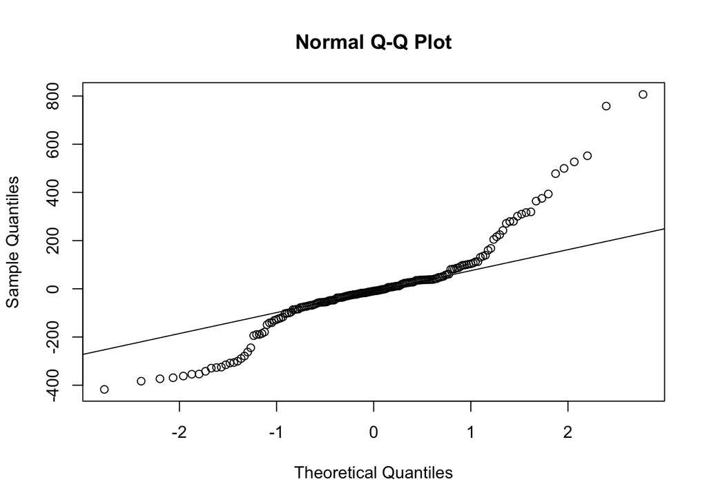

```r
qqnorm(EndovsSeq_m3$residuals)
qqline(EndovsSeq_m3$residuals)
```

For all tubes, the effect of time is investigated. The data is collapsed over RNA isolation method.

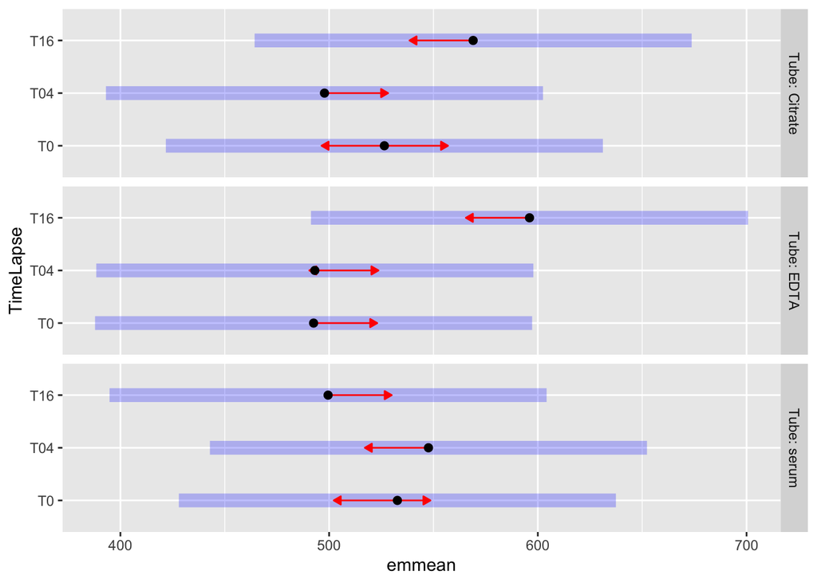

```r
EndovsSeq_m.time<-emmeans(EndovsSeq_m3, ~TimeLapse|Tube)
plot(EndovsSeq_m.time, comparisons=TRUE)
```

```r
pairs(EndovsSeq_m.time)
```

```
## Tube = Citrate:
##  contrast  estimate   SE df t.ratio p.value
##  T0 - T04    28.692 25.5 76   1.124  0.5022
##  T0 - T16   -42.534 25.5 76  -1.667  0.2247
##  T04 - T16  -71.226 25.5 76  -2.791  0.0180
##
## Tube = EDTA:
##  contrast  estimate   SE df t.ratio p.value
##  T0 - T04    -0.586 25.5 76  -0.023  0.9997
##  T0 - T16  -103.443 25.5 76  -4.053  0.0004
##  T04 - T16 -102.857 25.5 76  -4.030  0.0004
##
## Tube = serum:
##  contrast  estimate   SE df t.ratio p.value
##  T0 - T04   -14.885 25.5 76  -0.583  0.8295
##  T0 - T16    33.208 25.5 76   1.301  0.3989
##  T04 - T16   48.093 25.5 76   1.884  0.1502
##
## Results are averaged over the levels of: RNAisolation
## Degrees-of-freedom method: containment
## P value adjustment: tukey method for comparing a family of 3 estimates
```

```r
confint(EndovsSeq_m.time,adjust="mvt")
```

```
## Tube = Citrate:
##  TimeLapse emmean   SE df lower.CL upper.CL
##  T0           526 37.7  4      398      655
##  T04          498 37.7  4      370      626
##  T16          569 37.7  4      441      697
##
## Tube = EDTA:
##  TimeLapse emmean   SE df lower.CL upper.CL
##  T0           493 37.7  4      364      621
##  T04          493 37.7  4      365      622
##  T16          596 37.7  4      468      724
##
## Tube = serum:
##  TimeLapse emmean   SE df lower.CL upper.CL
##  T0           533 37.7  4      404      661
##  T04          548 37.7  4      419      676
##  T16          500 37.7  4      371      628
##
## Results are averaged over the levels of: RNAisolation
## Degrees-of-freedom method: containment
## Confidence level used: 0.95
## Conf-level adjustment: mvt method for 3 estimates
```

## 4.2 Relative RNA concentration in eluate: Endogenous vs ERCC

Linear mixed-effects model with crossed fixed effects of tube, kit and timelapse.

```r
EndovsERCC_m1<-lme(EndovsERCC~Tube*RNAisolation*TimeLapse,
       random=~1|donorID,
       weights = varIdent(form = ~ 1 | RNAisolation),
       data=conc_stat)

anova(EndovsERCC_m1)
```

```
##                             numDF denDF  F-value p-value
## (Intercept)                     1    68 115.6090  <.0001
## Tube                            2    68   1.6995  0.1905
## RNAisolation                    1    68 491.2657  <.0001
## TimeLapse                       2    68   3.4864  0.0362
## Tube:RNAisolation               2    68   2.2712  0.1110
## Tube:TimeLapse                  4    68   2.8336  0.0310
## RNAisolation:TimeLapse          2    68   3.1217  0.0505
## Tube:RNAisolation:TimeLapse     4    68   1.4079  0.2407
```

Borderline significant tube-time interaction. There is no third-order interaction with RNA isolation kit. Next, we look at second-order interactions:

```r
EndovsERCC_m2<-lme(EndovsERCC~(Tube+RNAisolation+TimeLapse)^2,
       random=~1|donorID,
       weights = varIdent(form = ~ 1 | RNAisolation),
       data=conc_stat)

anova(EndovsERCC_m2)
```

```
##                        numDF denDF  F-value p-value
## (Intercept)                1    72 114.6572  <.0001
## Tube                       2    72   1.6950  0.1908
## RNAisolation               1    72 475.7598  <.0001
## TimeLapse                  2    72   3.3753  0.0397
## Tube:RNAisolation          2    72   2.1996  0.1182
## Tube:TimeLapse             4    72   2.7698  0.0336
## RNAisolation:TimeLapse     2    72   3.0232  0.0549
```

Finally, we only include the tube-time interaction in the model.

```r
EndovsERCC_m3<-lme(EndovsERCC~Tube+RNAisolation+TimeLapse+
                     Tube:TimeLapse,
       random=~1|donorID,
       weights = varIdent(form = ~ 1 | RNAisolation),
       data=conc_stat)

anova(EndovsERCC_m3)
```

```
##                numDF denDF  F-value p-value
## (Intercept)        1    76 111.2121  <.0001
## Tube               2    76   1.6898  0.1914
## RNAisolation       1    76 423.9376  <.0001
## TimeLapse          2    76   3.0173  0.0548
## Tube:TimeLapse     4    76   2.5662  0.0448
```

The normality of the residuals is checked.

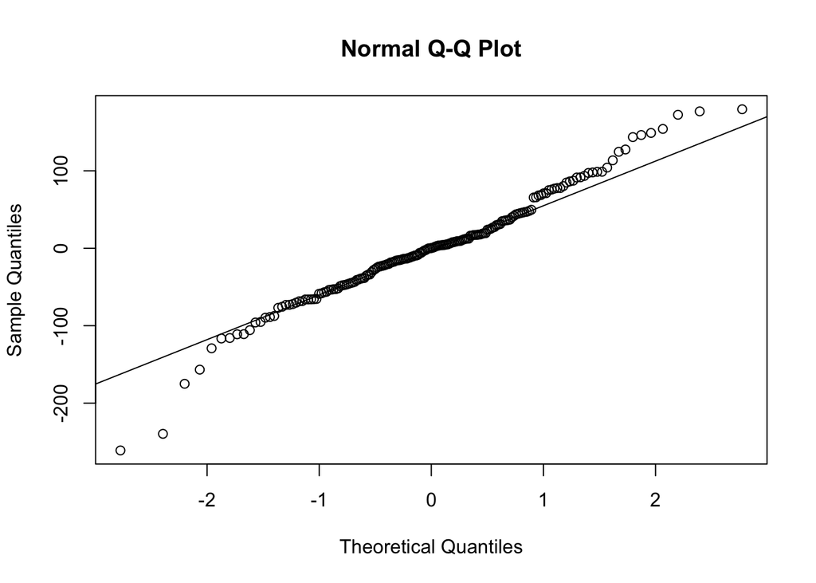

```r
qqnorm(EndovsERCC_m3$residuals)
qqline(EndovsERCC_m3$residuals)
```

For all tubes, the effect of time is investigated. The data is collapsed over RNA isolation method.

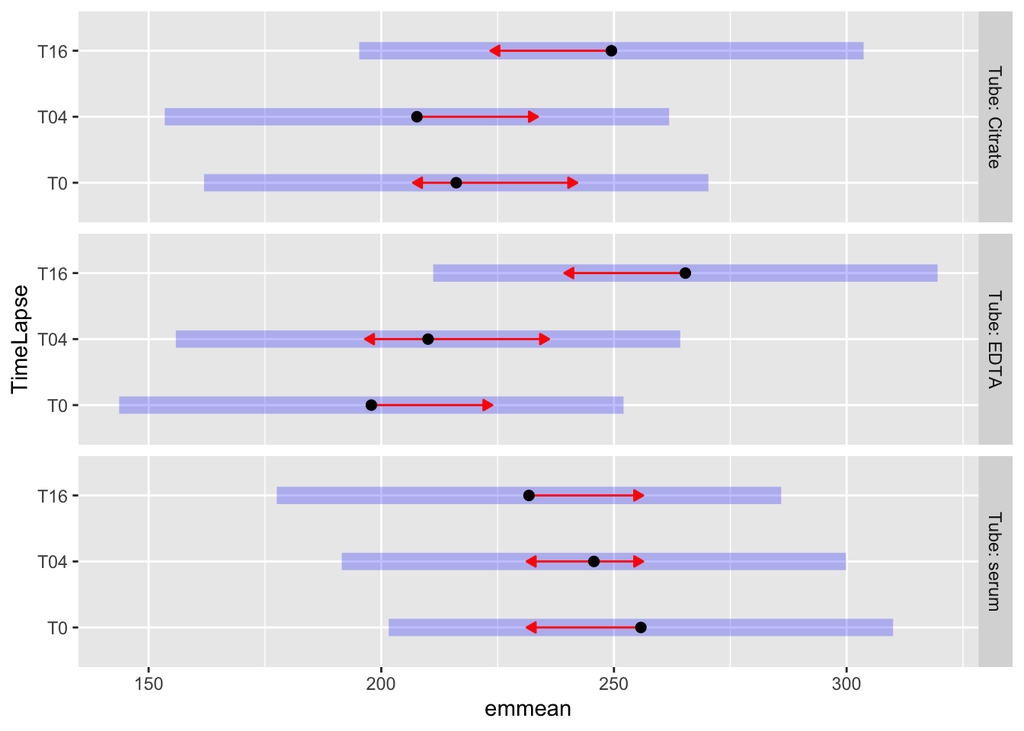

```r
EndovsERCC_m.time<-emmeans(EndovsERCC_m3, ~TimeLapse|Tube)
plot(EndovsERCC_m.time, comparisons=TRUE)
```

```r
pairs(EndovsERCC_m.time)
```

```
## Tube = Citrate:
##  contrast  estimate   SE df t.ratio p.value
##  T0 - T04      8.45 21.8 76   0.388  0.9203
##  T0 - T16    -33.35 21.8 76  -1.533  0.2813
##  T04 - T16   -41.80 21.8 76  -1.922  0.1396
##
## Tube = EDTA:
##  contrast  estimate   SE df t.ratio p.value
##  T0 - T04    -12.18 21.8 76  -0.560  0.8415
##  T0 - T16    -67.48 21.8 76  -3.103  0.0075
##  T04 - T16   -55.30 21.8 76  -2.542  0.0345
##
## Tube = serum:
##  contrast  estimate   SE df t.ratio p.value
##  T0 - T04     10.10 21.8 76   0.464  0.8882
##  T0 - T16     24.06 21.8 76   1.106  0.5133
##  T04 - T16    13.96 21.8 76   0.642  0.7976
##
## Results are averaged over the levels of: RNAisolation
## Degrees-of-freedom method: containment
## P value adjustment: tukey method for comparing a family of 3 estimates
```

```r
confint(EndovsERCC_m.time,adjust="mvt")
```

```
## Tube = Citrate:
##  TimeLapse emmean   SE df lower.CL upper.CL
##  T0           216 19.5  4      145      288
##  T04          208 19.5  4      136      279
##  T16          249 19.5  4      178      321
##
## Tube = EDTA:
##  TimeLapse emmean   SE df lower.CL upper.CL
##  T0           198 19.5  4      126      270
##  T04          210 19.5  4      138      282
##  T16          265 19.5  4      194      337
##
## Tube = serum:
##  TimeLapse emmean   SE df lower.CL upper.CL
##  T0           256 19.5  4      184      328
##  T04          246 19.5  4      174      317
##  T16          232 19.5  4      160      303
##
## Results are averaged over the levels of: RNAisolation
## Degrees-of-freedom method: containment
## Confidence level used: 0.95
## Conf-level adjustment: mvt method for 3 estimates
```

## 4.3 RNA extraction efficiency

Linear mixed-effects model with crossed fixed effects of tube, kit and timelapse.

```r
EndovsERCC_InputCorr_m1<-lme(EndovsERCC_InputCorr~Tube*RNAisolation*TimeLapse,
       random=~1|donorID,
       weights = varIdent(form = ~ 1 | RNAisolation),
       data=conc_stat)

anova(EndovsERCC_InputCorr_m1)
```

```
##                             numDF denDF   F-value p-value
## (Intercept)                     1    68 185.61122  <.0001
## Tube                            2    68   1.77026  0.1780
## RNAisolation                    1    68  57.30531  <.0001
## TimeLapse                       2    68   7.25478  0.0014
## Tube:RNAisolation               2    68   2.25556  0.1126
## Tube:TimeLapse                  4    68   3.69286  0.0088
## RNAisolation:TimeLapse          2    68   0.28284  0.7545
## Tube:RNAisolation:TimeLapse     4    68   0.87872  0.4814
```

```r
anova_EndovsERCC_InputCorr_m1 <- round(anova(EndovsERCC_InputCorr_m1)[c(5, 6, 7), c(4)], digits = 3)
```

The model indicates a significant tube-time interaction. There is no third-order interaction with RNA isolation kit. Next, we look at second-order interactions:

```r
EndovsERCC_InputCorr_m2<-lme(EndovsERCC_InputCorr~(Tube+RNAisolation+TimeLapse)^2,
       random=~1|donorID,
       weights = varIdent(form = ~ 1 | RNAisolation),
       data=conc_stat)

anova(EndovsERCC_InputCorr_m2)
```

```
##                        numDF denDF   F-value p-value
## (Intercept)                1    72 185.46415  <.0001
## Tube                       2    72   1.76938  0.1778
## RNAisolation               1    72  57.97366  <.0001
## TimeLapse                  2    72   7.26638  0.0013
## Tube:RNAisolation          2    72   2.28187  0.1094
## Tube:TimeLapse             4    72   3.70089  0.0085
## RNAisolation:TimeLapse     2    72   0.28614  0.7520
```

Again, we see a significant tube-time interaction. Finally, we only include the tube-time interaction in the model.

```r
EndovsERCC_InputCorr_m3<-lme(EndovsERCC_InputCorr~Tube+RNAisolation+TimeLapse+
             Tube:TimeLapse,
       random=~1|donorID,
       weights = varIdent(form = ~ 1 | RNAisolation),
       data=conc_stat)

anova(EndovsERCC_InputCorr_m3)
```

```
##                numDF denDF   F-value p-value
## (Intercept)        1    76 185.77141  <.0001
## Tube               2    76   1.77126  0.1771
## RNAisolation       1    76  56.57807  <.0001
## TimeLapse          2    76   7.24223  0.0013
## Tube:TimeLapse     4    76   3.68416  0.0085
```

Check of normality of the residuals.

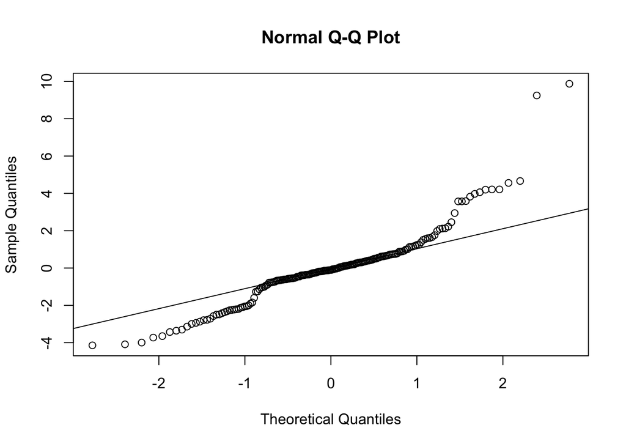

```r
qqnorm(EndovsERCC_InputCorr_m3$residuals)
qqline(EndovsERCC_InputCorr_m3$residuals)
```

For all tubes, the effect of time is investigated. The data is collapsed over RNA isolation method.

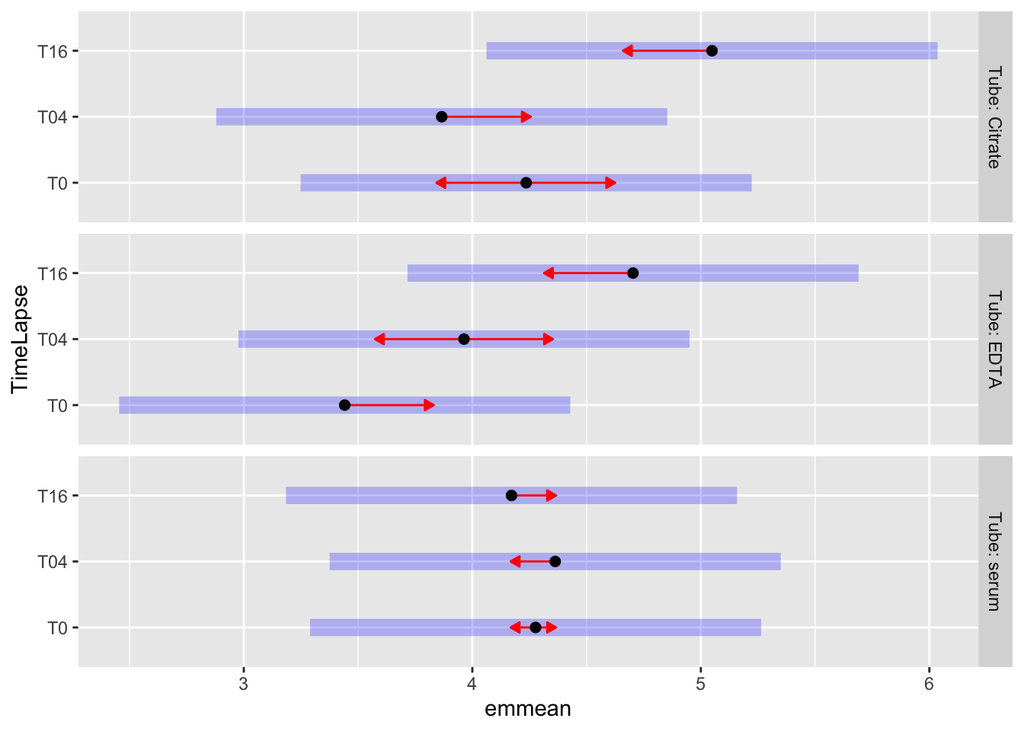

```r
EndovsERCC_InputCorr_m.time<-emmeans(EndovsERCC_InputCorr_m3, ~TimeLapse|Tube)
plot(EndovsERCC_InputCorr_m.time, comparisons=TRUE)
```

```r
pairs(EndovsERCC_InputCorr_m.time)
```

```
## Tube = Citrate:
##  contrast  estimate    SE df t.ratio p.value
##  T0 - T04    0.3695 0.326 76   1.133  0.4970
##  T0 - T16   -0.8132 0.326 76  -2.493  0.0390
##  T04 - T16  -1.1827 0.326 76  -3.626  0.0015
##
## Tube = EDTA:
##  contrast  estimate    SE df t.ratio p.value
##  T0 - T04   -0.5219 0.326 76  -1.600  0.2518
##  T0 - T16   -1.2617 0.326 76  -3.868  0.0007
##  T04 - T16  -0.7398 0.326 76  -2.268  0.0666
##
## Tube = serum:
##  contrast  estimate    SE df t.ratio p.value
##  T0 - T04   -0.0859 0.326 76  -0.263  0.9625
##  T0 - T16    0.1052 0.326 76   0.322  0.9443
##  T04 - T16   0.1911 0.326 76   0.586  0.8281
##
## Results are averaged over the levels of: RNAisolation
## Degrees-of-freedom method: containment
## P value adjustment: tukey method for comparing a family of 3 estimates
```

```r
confint(EndovsERCC_InputCorr_m.time,adjust="mvt")
```

```
## Tube = Citrate:
##  TimeLapse emmean    SE df lower.CL upper.CL
##  T0          4.24 0.356  4     2.97     5.51
##  T04         3.87 0.356  4     2.60     5.14
##  T16         5.05 0.356  4     3.78     6.32
##
## Tube = EDTA:
##  TimeLapse emmean    SE df lower.CL upper.CL
##  T0          3.44 0.356  4     2.17     4.71
##  T04         3.96 0.356  4     2.70     5.23
##  T16         4.70 0.356  4     3.43     5.97
##
## Tube = serum:
##  TimeLapse emmean    SE df lower.CL upper.CL
##  T0          4.28 0.356  4     3.01     5.55
##  T04         4.36 0.356  4     3.09     5.63
##  T16         4.17 0.356  4     2.90     5.44
##
## Results are averaged over the levels of: RNAisolation
## Degrees-of-freedom method: containment
## Confidence level used: 0.95
## Conf-level adjustment: mvt method for 3 estimates
```

Both in the EDTA en citrate tubes there seems to be a significantly higher extraction efficiency at timepoint 16h.

# 5 Gene count

## 5.1 absolute numbers

```r
gene_stat <- read.csv('./data_output/number_genes_detected.csv',sep=",",header = TRUE)

gene_stat$Tube<-as.factor(gene_stat$Tube)
gene_stat$RNAisolation<-as.factor(gene_stat$RNAisolation)
gene_stat$TimeLapse<-as.factor(gene_stat$TimeLapse)
gene_stat$donorID<-as.factor(gene_stat$donorID)

Tube.levels<-levels(gene_stat$Tube)
RNAisolation.levels<-levels(gene_stat$RNAisolation)
TimeLapse.levels<-levels(gene_stat$TimeLapse)
```

Linear mixed-effects model with crossed fixed effects of tube, kit and timelapse.

```r
count_m1<-lme(genes_aboveTh~Tube*RNAisolation*TimeLapse,
       random=~1|donorID,
       weights = varIdent(form = ~ 1 | RNAisolation),
       data=gene_stat)

anova(count_m1)
```

```
##                             numDF denDF   F-value p-value
## (Intercept)                     1    68 313.30761  <.0001
## Tube                            2    68  17.80049  <.0001
## RNAisolation                    1    68 280.31382  <.0001
## TimeLapse                       2    68   0.30821  0.7358
## Tube:RNAisolation               2    68   5.67813  0.0052
## Tube:TimeLapse                  4    68   2.00919  0.1030
## RNAisolation:TimeLapse          2    68   0.95604  0.3895
## Tube:RNAisolation:TimeLapse     4    68   1.38852  0.2472
```

```r
anova_count_m1 <- round(anova(count_m1)[c(5, 6, 7), c(4)], digits = 3)
```

There seems to be a significant tube-RNA isolation kit interaction. There is no third-order interaction with time. Next, we look at second-order interactions:

```r
count_m2<-lme(genes_aboveTh~(Tube+RNAisolation+TimeLapse)^2,
       random=~1|donorID,
       weights = varIdent(form = ~ 1 | RNAisolation),
       data=gene_stat)

anova(count_m2)
```

```
##                        numDF denDF   F-value p-value
## (Intercept)                1    72 313.01274  <.0001
## Tube                       2    72  17.38210  <.0001
## RNAisolation               1    72 274.31953  <.0001
## TimeLapse                  2    72   0.30091  0.7411
## Tube:RNAisolation          2    72   5.55671  0.0057
## Tube:TimeLapse             4    72   1.96416  0.1091
## RNAisolation:TimeLapse     2    72   0.93559  0.3971
```

Finally, we only include the tube-kit interaction in the model.

```r
count_m3<-lme(genes_aboveTh~Tube+RNAisolation+TimeLapse+
             Tube:RNAisolation,
       random=~1|donorID,
       weights = varIdent(form = ~ 1 | RNAisolation),
       data=gene_stat)

anova(count_m3)
```

```
##                   numDF denDF   F-value p-value
## (Intercept)           1    78 306.12500  <.0001
## Tube                  2    78  15.71216  <.0001
## RNAisolation          1    78 260.15319  <.0001
## TimeLapse             2    78   0.27352  0.7614
## Tube:RNAisolation     2    78   5.26975  0.0071
```

Check of normality of the residuals.

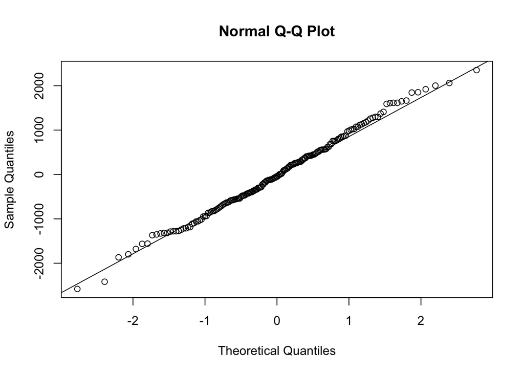

```r
qqnorm(count_m3$residuals)
qqline(count_m3$residuals)
```

For both RNA isolation methods, the effect of tube is investigated. The data is collapsed over time.

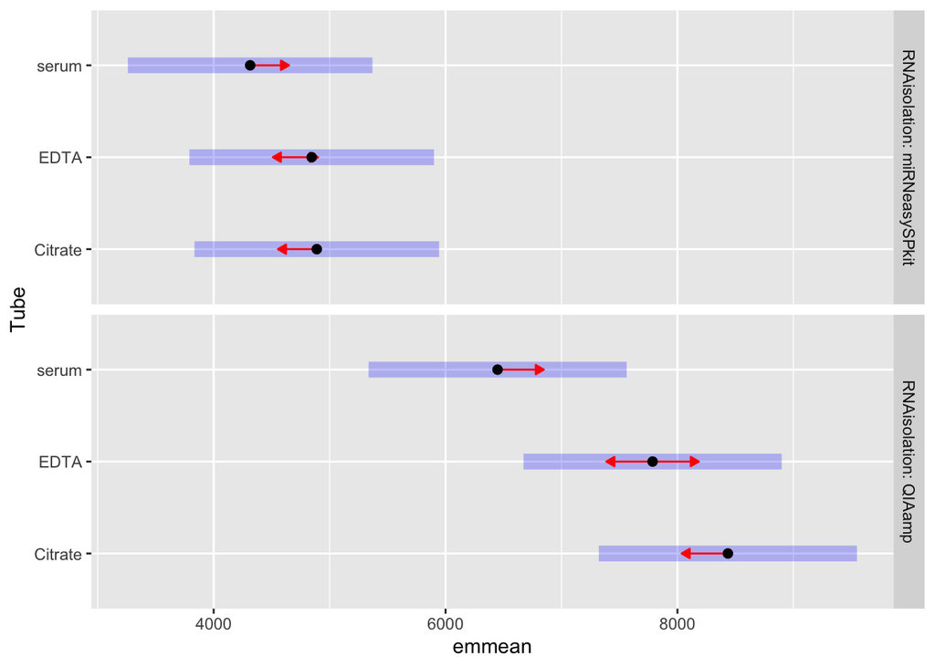

```r
count_m.methods<-emmeans(count_m3, ~Tube|RNAisolation)
plot(count_m.methods, comparisons=TRUE)
```

```r
pairs(count_m.methods)
```

```
## RNAisolation = miRNeasySPkit:
##  contrast        estimate  SE df t.ratio p.value
##  Citrate - EDTA        44 281 78   0.157  0.9866
##  Citrate - serum      575 281 78   2.046  0.1080
##  EDTA - serum         531 281 78   1.890  0.1484
##
## RNAisolation = QIAamp:
##  contrast        estimate  SE df t.ratio p.value
##  Citrate - EDTA       649 334 78   1.944  0.1332
##  Citrate - serum     1986 334 78   5.947  <.0001
##  EDTA - serum        1337 334 78   4.002  0.0004
##
## Results are averaged over the levels of: TimeLapse
## Degrees-of-freedom method: containment
## P value adjustment: tukey method for comparing a family of 3 estimates
```

```r
confint(count_m.methods, adjust="mvt")
```

```
## RNAisolation = miRNeasySPkit:
##  Tube    emmean  SE df lower.CL upper.CL
##  Citrate   4889 380  4     3578     6201
##  EDTA      4845 380  4     3534     6157
##  serum     4315 380  4     3004     5626
##
## RNAisolation = QIAamp:
##  Tube    emmean  SE df lower.CL upper.CL
##  Citrate   8435 401  4     7027     9843
##  EDTA      7786 401  4     6377     9194
##  serum     6449 401  4     5041     7857
##
## Results are averaged over the levels of: TimeLapse
## Degrees-of-freedom method: containment
## Confidence level used: 0.95
## Conf-level adjustment: mvt method for 3 estimates
```

Serum has a significantly lower absolute count of protein-coding genes, but only if extracted with the QIAamp kit.

Pairwise T-test within kits

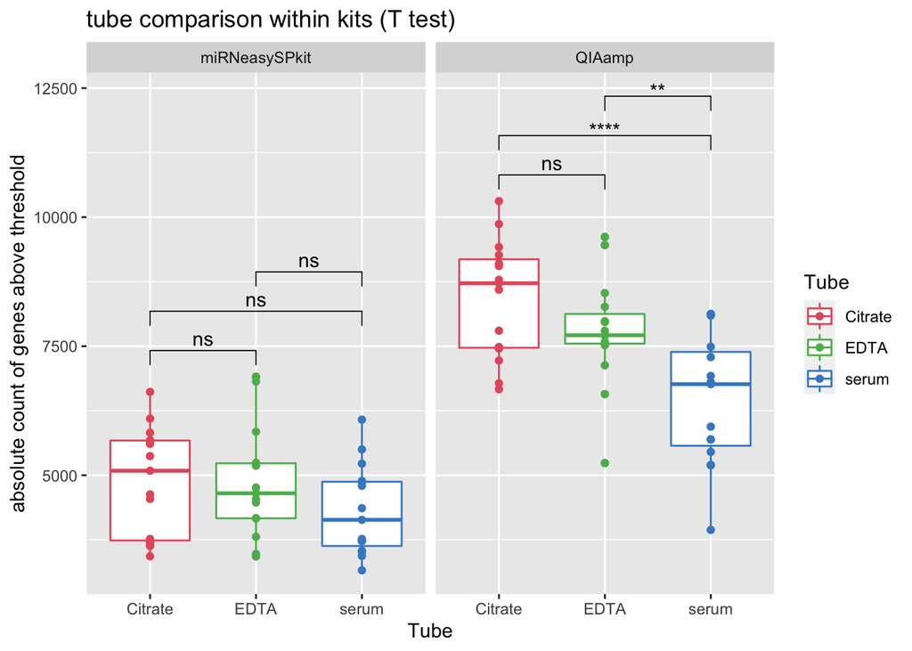

```r
# Pairwise comparisons
gene_pwc <- gene_stat %>% group_by(RNAisolation) %>% pairwise_t_test(genes_aboveTh ~ Tube) %>% add_xy_position(x = "Tube")

# Show p-values
ggplot(gene_stat, aes(x = Tube, y = genes_aboveTh, color = Tube)) +
  geom_boxplot()+
  geom_point()+
  scale_colour_manual(values=color_panel)+
  facet_wrap(~ RNAisolation) +
  stat_pvalue_manual(gene_pwc, label = "p.signif") +
  labs(title = "tube comparison within kits (T test)", y = "absolute count of genes above threshold")
```

```r
#ggsave("./data_output/plots/duplicates_stats.pdf", plot = ggplot2::last_plot(), dpi = 300)
```

# 6 Area left of the curve (ALC)

```r
ALC <- read.csv('./data_output/ALC.csv',sep=",",header = TRUE)

ALC[c("Tube","RNAisolation")] <- str_split_fixed(ALC$tube_kitID, "_", 2)
ALC$Tube <- as.factor(ALC$Tube)
ALC$RNAisolation <- as.factor(ALC$RNAisolation)
ALC$TimePoint <- as.factor(ALC$TimePoint)
ALC$BiologicalReplicate <- as.factor(ALC$BiologicalReplicate)
ALC <- na.omit(ALC)
```

Linear mixed-effects model with crossed fixed effects of tube, kit and timelapse.

```r
ALC_m1<-lme(ALC_calc~Tube*RNAisolation*TimePoint,
       random=~1|BiologicalReplicate,
       weights = varIdent(form = ~ 1 | RNAisolation),
       data=ALC)

anova(ALC_m1)
```

```
##                             numDF denDF  F-value p-value
## (Intercept)                     1    44 776.6554  <.0001
## Tube                            2    44   2.8118  0.0709
## RNAisolation                    1    44  10.8255  0.0020
## TimePoint                       1    44   0.1389  0.7112
## Tube:RNAisolation               2    44   0.2600  0.7723
## Tube:TimePoint                  2    44   0.4628  0.6325
## RNAisolation:TimePoint          1    44   0.0370  0.8484
## Tube:RNAisolation:TimePoint     2    44   0.4545  0.6377
```

```r
anova_ALC_m1 <- round(anova(ALC_m1)[c(5, 6, 7), c(4)], digits = 3)
```

Next, we look at second-order interactions:

```r
ALC_m2<-lme(ALC_calc~(Tube+RNAisolation+TimePoint)^2,
       random=~1|BiologicalReplicate,
       weights = varIdent(form = ~ 1 | RNAisolation),
       data=ALC)

anova(ALC_m2)
```

```
##                        numDF denDF  F-value p-value
## (Intercept)                1    46 767.8574  <.0001
## Tube                       2    46   2.8738  0.0667
## RNAisolation               1    46  11.1645  0.0017
## TimePoint                  1    46   0.1428  0.7072
## Tube:RNAisolation          2    46   0.2681  0.7660
## Tube:TimePoint             2    46   0.4647  0.6312
## RNAisolation:TimePoint     1    46   0.0382  0.8460
```

There are no significant interactions.

Check of normality of the residuals.

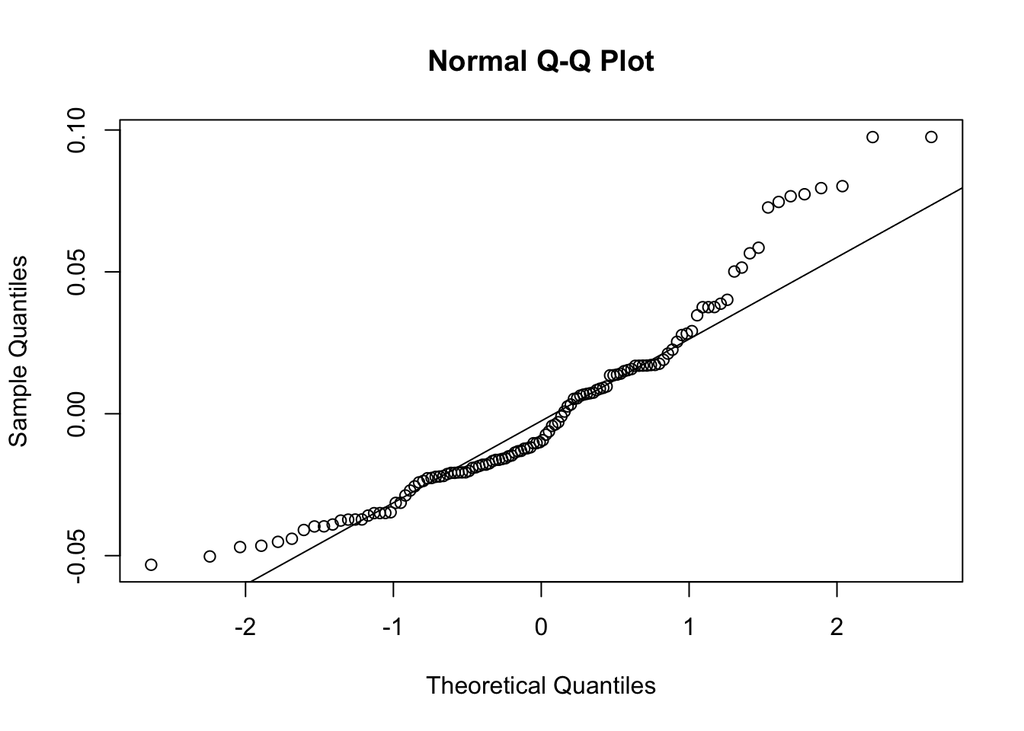

```r
qqnorm(ALC_m1$residuals)
qqline(ALC_m1$residuals)
```

# 7 conclusion

For duplicates and gene count, we see a tube-kit interaction. For both metrics the serum tube combined with the QIAamp extraction kit seems to perform worse than the other combinations. For RNA concentration and extraction efficiency, there seems to be a tube-time interaction. The EDTA tube at timepoint 16h performs significantly better than other combinations. In case of Extraction efficiency, this is also the case with the citrate tube.

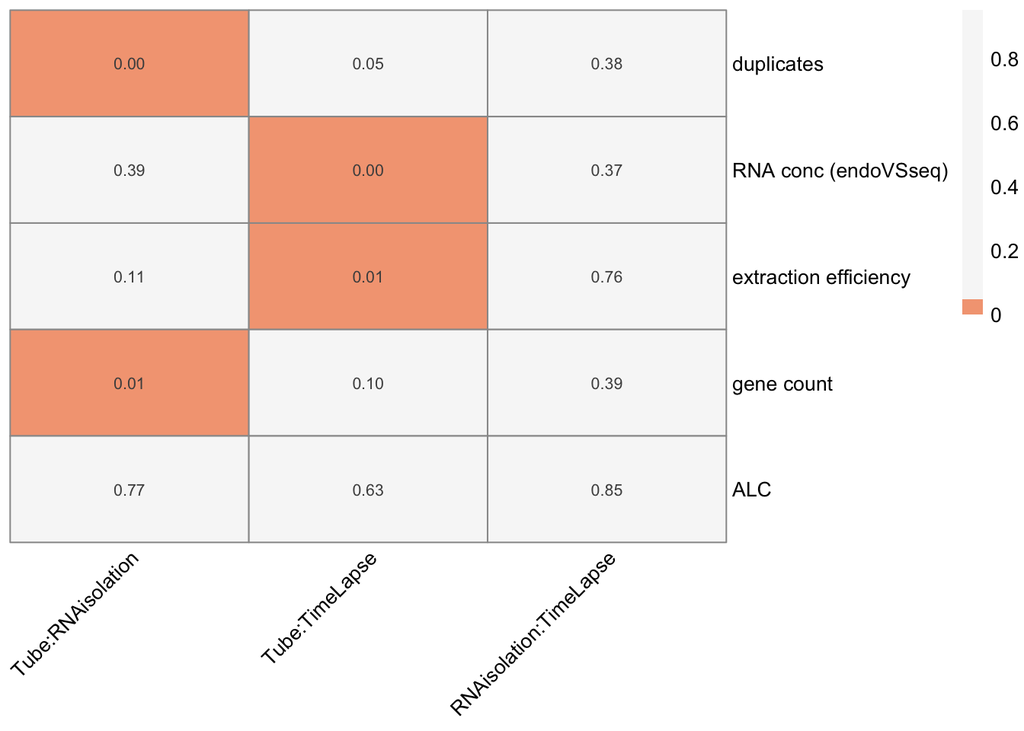

```r
overview <- data.frame(row.names = c("Tube:RNAisolation","Tube:TimeLapse","RNAisolation:TimeLapse"), "duplicates"= anova_dupl_m1, "RNA conc (endoVSseq)" = anova_EndovsSeq_m1, "extraction efficiency" = anova_EndovsERCC_InputCorr_m1, "gene count" = anova_count_m1, "ALC" = anova_ALC_m1, check.names = FALSE)
overview_t <- t(overview)
# add row with which interaction was significant
#significant <- data.frame("None","Serum-QIAamp","None","None","None","None", row.names = "significant")
#names(significant) <- names(overview)
#overview <- rbind(overview, significant)
# table
#DT::datatable(overview) %>%
#  DT::formatStyle(3, target = "row") #fontWeight = styleEqual(3, "bold")
# heatmap
## apply different color for p < 0.05
bk1 <- c(seq(0,0.04,by=0.01),0.049)
bk2 <- c(seq(0.05,1,by=0.1))
bk <- c(bk1,bk2)
custom_palette <- c(colorRampPalette(colors = c("#F4A582"))(length(bk1)-1), colorRampPalette(colors = c('#F7F7F7'))(length(bk2)-1))
pheatmap::pheatmap(overview_t,
                   breaks = bk,
                   display_numbers = T,
                   color = custom_palette,
                   angle_col = 45,
                   cluster_rows=FALSE, cluster_cols=FALSE)
```